# Praktikum 2

Reyzha Siva Dewi

2023-12-16

```r
data <- read.csv("E:/Semester 5/MPDW/NewDelhi_Air_quality.csv")
View(data)
```

### Pemanggilan Packages

```r
library(dplyr)
library(TTR)
library(forecast)
library(lmtest) #digunakan untuk uji formal pendeteksian autokorelasi
library(orcutt) #untuk membuat model regresi Cochrane-Orcutt
library(HoRM) #untuk membuat model regresi Hildreth-Lu
```

### Input Data

```r
data <- read.csv("E:/Semester 5/MPDW/NewDelhi_Air_quality.csv")
```

## Eksplorasi Data

### Membentuk objek time series

```r
data.ts1 <- ts(data$so2)
data.ts2 <- ts(data$pm25)
data.ts3 <- ts(data$o3)
```

### Membuat plot time series

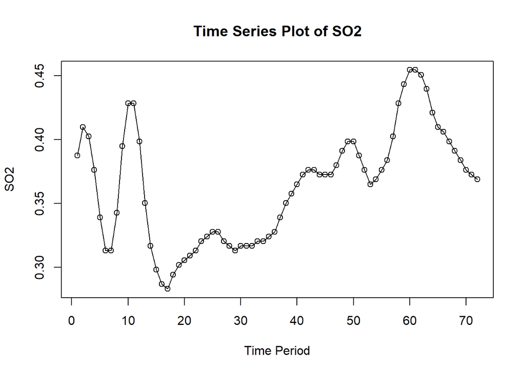

```r
ts.plot(data.ts1, xlab="Time Period", ylab="SO2", main = "Time Series Plot of SO2")
points(data.ts1)
```

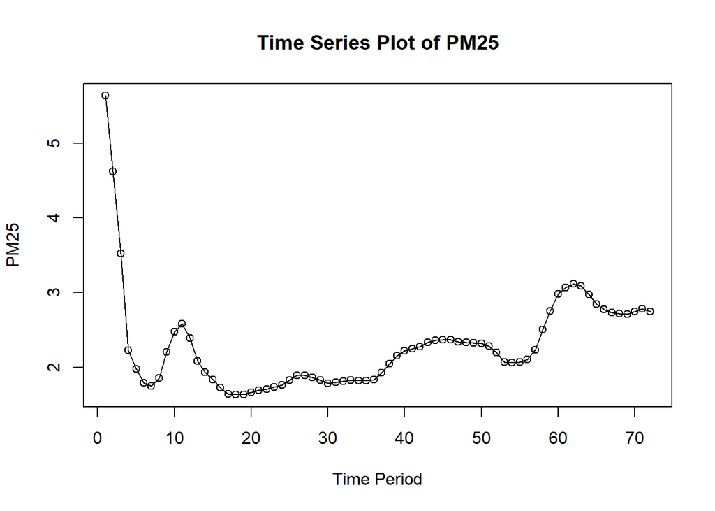

```r
ts.plot(data.ts2, xlab="Time Period", ylab="PM25", main = "Time Series Plot of PM25")
points(data.ts2)
```

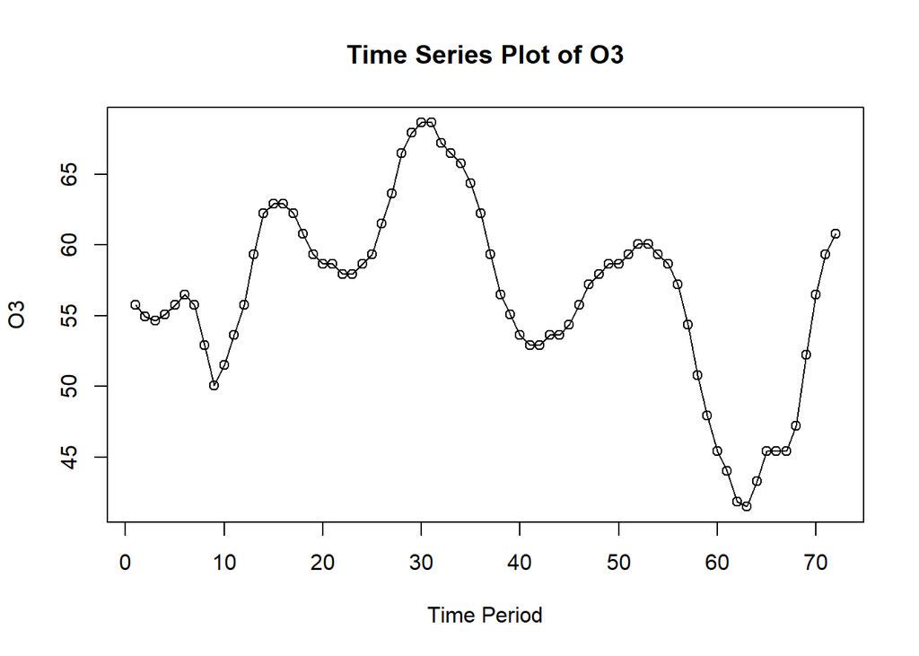

```r
ts.plot(data.ts3, xlab="Time Period", ylab="O3", main = "Time Series Plot of O3")
points(data.ts3)
```

## Regresi

### Model Regresi

```r
model <- lm(data$AQI~data$so2+data$pm25+data$o3)
model
```

```
##
## Call:
## lm(formula = data$AQI ~ data$so2 + data$pm25 + data$o3)
##
## Coefficients:
## (Intercept)     data$so2    data$pm25      data$o3
##     -0.7861      -8.6494       1.2469       0.4817
```

```r
summary(model)
```

```
##
## Call:
## lm(formula = data$AQI ~ data$so2 + data$pm25 + data$o3)
##
## Residuals:
##      Min       1Q   Median       3Q      Max
## -1.05200 -0.25356  0.04255  0.25378  0.59911
##
## Coefficients:
##             Estimate Std. Error t value Pr(>|t|)
## (Intercept) -0.78613    1.04224  -0.754    0.453
## data$so2    -8.64939    1.67151  -5.175  2.2e-06 ***
## data$pm25    1.24686    0.08249  15.116  < 2e-16 ***
## data$o3      0.48165    0.01005  47.931  < 2e-16 ***
## ---
## Signif. codes:  0 '***' 0.001 '**' 0.01 '*' 0.05 '.' 0.1 ' ' 1
##
## Residual standard error: 0.3369 on 68 degrees of freedom
## Multiple R-squared:  0.9884, Adjusted R-squared:  0.9878
## F-statistic:  1923 on 3 and 68 DF,  p-value: < 2.2e-16
```

### Sisaan dan fitted value

```r
sisaan <- residuals(model)
fitValue <- predict(model)
```

### Diagnostik dengan eksploratif

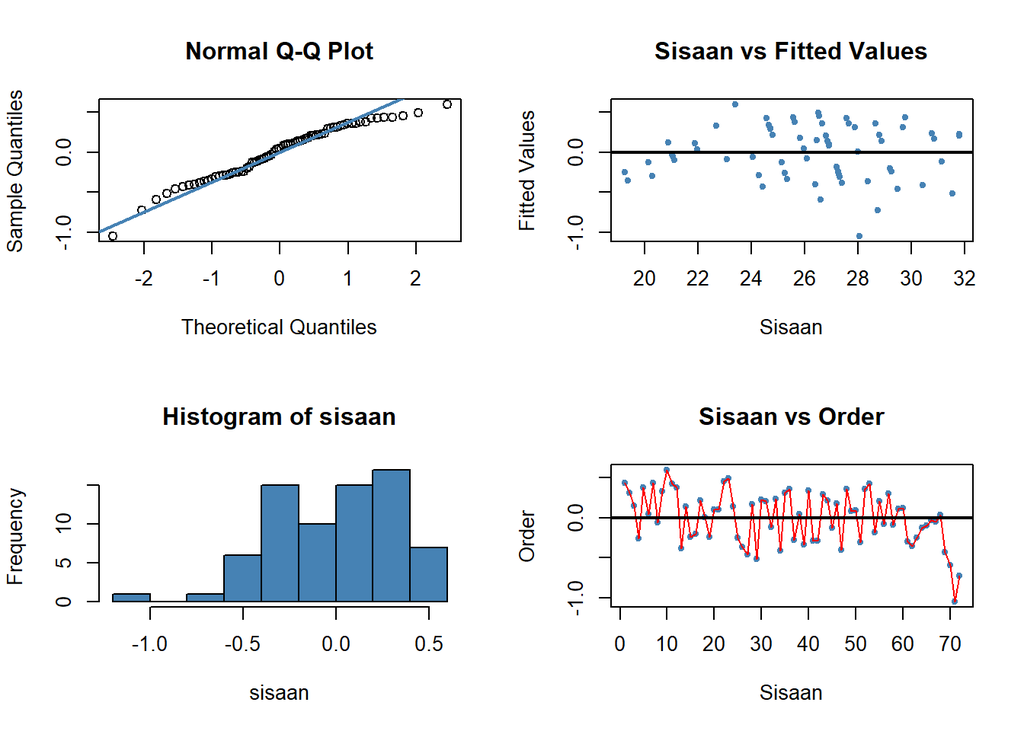

```r
par(mfrow = c(2,2))
qqnorm(sisaan)
qqline(sisaan, col = "steelblue", lwd = 2)
plot(fitValue, sisaan, col = "steelblue", pch = 20, xlab = "Sisaan", ylab = "Fitted Values", main = "Sisaan vs Fitted Values")
abline(a = 0, b = 0, lwd = 2)
hist(sisaan, col = "steelblue")
plot(seq(1, 72, 1), sisaan, col = "steelblue", pch = 20, xlab = "Sisaan", ylab = "Order", main = "Sisaan vs Order")
lines(seq(1,72,1), sisaan, col = "red")
abline(a = 0, b = 0, lwd = 2)
```

Dua plot di samping kiri digunakan untuk melihat apakah sisaan menyebar normal. Normal Q-Q Plot di atas menunjukkan bahwa sisaan cenderung menyebar normal, tetapi histogram dari sisaan tidak menunjukkan demikian. Selanjutnya, dua plot di samping kanan digunakan untuk melihat autokorelasi. Plot Sisaan vs *Fitted Value* dan Plot Sisaan vs *Order* menunjukkan adanya pola pada sisaan. Untuk lebih lanjut akan digunakan uji formal melihat normalitas sisaan dan plot ACF dan PACF untuk melihat apakah ada autokorelasi atau tidak.

### Melihat sisaan menyebar normal/tidak

H0: sisaan mengikuti sebaran normal

H1: sisaan tidak mengikuti sebaran normal

```r
shapiro.test(sisaan)
```

```
##
##  Shapiro-Wilk normality test
##
## data:  sisaan
## W = 0.96638, p-value = 0.05112
```

```r
ks.test(sisaan, "pnorm", mean=mean(sisaan), sd=sd(sisaan))
```

```
##
##  Exact one-sample Kolmogorov-Smirnov test
##
## data:  sisaan
## D = 0.089446, p-value = 0.5808
## alternative hypothesis: two-sided
```

Nilai p-value dari hasil uji di atas bernilai di atas 0.05 atau nilai alphanya (5%). Artinya, cukup bukti untuk menyatakan sisaan berdistribusi normal

#### ACF dan PACF identifikasi autokorelasi

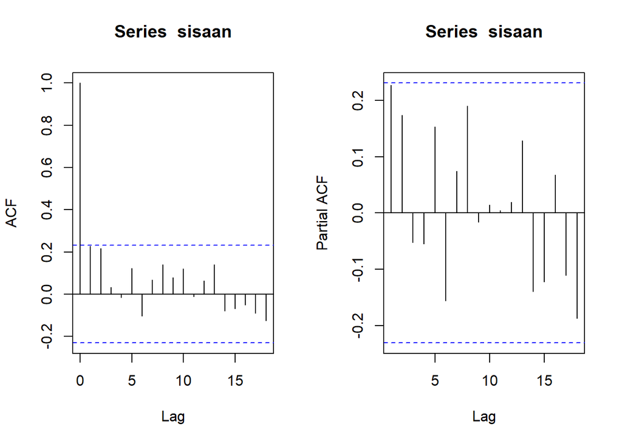

```r
par(mfrow = c(1,2))

acf(sisaan)

pacf(sisaan)
```

Untuk lebih memastikan akan dilakukan uji formal dengan uji Durbin Watson.

### Deteksi autokorelasi dengan uji-Durbin Watson

H0: tidak ada autokorelasi

H1: ada autokorelasi

```r
dwtest(model)
```

```
##
##  Durbin-Watson test
##
## data:  model
## DW = 1.4525, p-value = 0.003315
## alternative hypothesis: true autocorrelation is greater than 0
```

## Penanganan Autokorelasi

### Metode Cochrane-Orcutt

```r
modelco <- cochrane.orcutt(model)
modelco
```

```
## Cochrane-orcutt estimation for first order autocorrelation
##
## Call:
## lm(formula = data$AQI ~ data$so2 + data$pm25 + data$o3)
##
##  number of interaction: 9
##  rho 0.249237
##
## Durbin-Watson statistic
## (original):    1.45247 , p-value: 3.315e-03
## (transformed): 2.26799 , p-value: 7.894e-01
##
##  coefficients:
## (Intercept)    data$so2   data$pm25     data$o3
##   -0.842414   -6.063489    0.923918    0.478611
```

### Rho optimum

```r
rho<- modelco$rho

rho
```

```
## [1] 0.2492367
```

### Transformasi Manual

```r
aqi.trans<- data$AQI[-1]-data$AQI[-72]*rho
so2.trans<- data$so2[-1]-data$so2[-72]*rho
pm25.trans <- data$pm25[-1]-data$pm25[-72]
o3.trans <- data$o3[-1]-data$o3[-72]
modelCOmanual<- lm(aqi.trans~so2.trans+pm25.trans+o3.trans)
summary(modelCOmanual)
```

```
##
## Call:
## lm(formula = aqi.trans ~ so2.trans + pm25.trans + o3.trans)
##
## Residuals:
##      Min       1Q   Median       3Q      Max
## -2.73974 -1.07011 -0.02952  1.28063  2.88180
##
## Coefficients:
##             Estimate Std. Error t value Pr(>|t|)
## (Intercept)  33.0665     1.4600  22.648   <2e-16 ***
## so2.trans   -49.5006     5.3077  -9.326    1e-13 ***
## pm25.trans   -0.4124     0.7193  -0.573    0.568
## o3.trans      0.1706     0.1039   1.641    0.105
## ---
## Signif. codes:  0 '***' 0.001 '**' 0.01 '*' 0.05 '.' 0.1 ' ' 1
##
## Residual standard error: 1.519 on 67 degrees of freedom
## Multiple R-squared:  0.5922, Adjusted R-squared:  0.5739
## F-statistic: 32.43 on 3 and 67 DF,  p-value: 4.574e-13
```

```r
#Mencari Penduga Koefisien Regresi setelah Transformasi ke Persamaan Awal

b0bintang <- modelCOmanual$coefficients[1]

b0 <- b0bintang/(1-rho)

b1 <- modelCOmanual$coefficients[2]
b2 <- modelCOmanual$coefficients[3]
b3 <- modelCOmanual$coefficients[4]

b0
```

```
## (Intercept)
##    44.04386
```

```r
b1
```

```
## so2.trans
## -49.50062
```

```r
b2
```

```
## pm25.trans
## -0.4124368
```

```r
b3
```

```
##  o3.trans
## 0.1705973
```

### Metode Hildreth-Lu

Penanganan kedua adalah menggunakan metode Hildreth-Lu. Metode ini akan mencari nilai SSE terkecil dan dapat dicari secara manual maupun menggunakan packages. Jika menggunakan packages, gunakan `library` *packages* `HORM`.

#### Penanganan Autokorelasi Hildreth lu

```r
hildreth.lu.func<- function(r, model){

  x1 <- model.matrix(model)[,2]
  x2 <- model.matrix(model)[,3]
  x3 <- model.matrix(model)[,4]

  y <- model.response(model.frame(model))
  n <- length(y)
  t <- 2:n
  y <- y[t]-r*y[t-1]
  x1 <- x1[t]-r*x1[t-1]
  x2 <- x2[t]-r*x2[t-1]
  x3 <- x3[t]-r*x3[t-1]



  return(lm(y~x1+x2+x3))

}
```

#### Pencarian rho yang meminimumkan SSE

```r
r <- c(seq(0.1,0.9, by= 0.1))

tab <- data.frame("rho" = r, "SSE" = sapply(r, function(i){deviance(hildreth.lu.func(i, model))}))

round(tab, 4)
```

```
##   rho     SSE
## 1 0.1  6.9483
## 2 0.2  6.7981
## 3 0.3  6.8000
## 4 0.4  6.9710
## 5 0.5  7.3400
## 6 0.6  7.9011
## 7 0.7  8.5597
## 8 0.8  9.2704
## 9 0.9 10.0822
```

Pertama-tama akan dicari di mana kira-kira $ρ$ yang menghasilkan SSE minimum. Pada hasil di atas terlihat $ρ$ minimum ketika 0.2. Namun, hasil tersebut masih kurang teliti sehingga akan dicari kembali $ρ$ yang lebih optimum dengan ketelitian yang lebih. Jika sebelumnya jarak antar $ρ$ yang dicari adalah 0.1, kali ini jarak antar $ρ$ adalah 0.001 dan dilakukan pada selang 0.1 sampai dengan 0.3.

```r
#Rho optimal di sekitar 0.9

rOpt <- seq(0.1,0.3, by= 0.001)

tabOpt <- data.frame("rho" = rOpt, "SSE" = sapply(rOpt, function(i){deviance(hildreth.lu.func(i, model))}))

head(tabOpt[order(tabOpt$SSE),])
```

```
##       rho      SSE
## 150 0.249 6.779260
## 151 0.250 6.779265
## 149 0.248 6.779272
## 152 0.251 6.779285
## 148 0.247 6.779299
## 153 0.252 6.779320
```

Perhitungan yang dilakukan aplikasi `R` menunjukkan bahwa nilai $ρ$ optimum, yaitu saat SSE terkecil terdapat pada nilai $ρ=0.249$. Hal tersebut juga ditunjukkan pada plot. Selanjutnya, model dapat didapatkan dengan mengevaluasi nilai $ρ$ ke dalam fungsi `hildreth.lu.func`, serta dilanjutkan dengan pengujian autokorelasi dengan uji Durbin-Watson. Namun, setelah pengecekan tersebut tidak lupa koefisien regresi tersebut digunakan untuk transformasi balik. Persamaan hasil transformasi itulah yang menjadi persamaan sesungguhnya.

#### SSE optimum

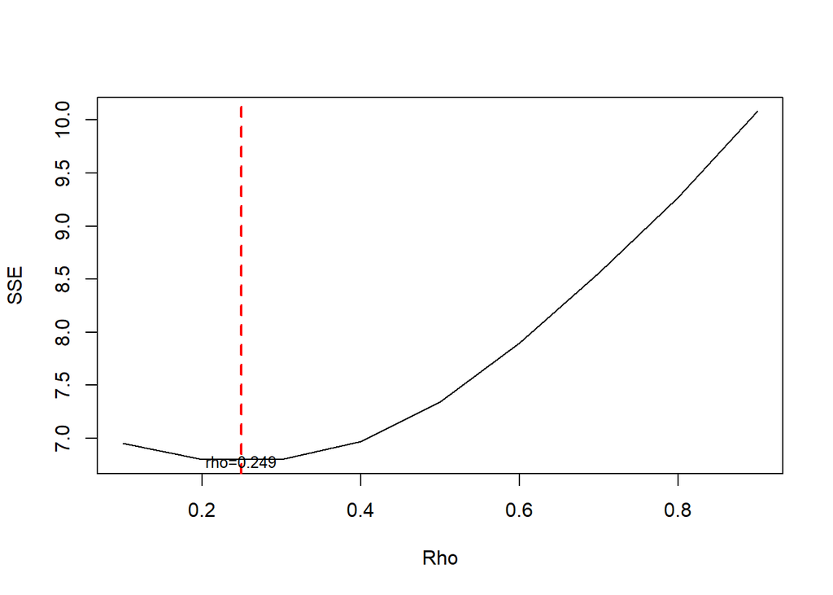

```r
par(mfrow = c(1,1))

plot(tab$SSE ~ tab$rho , type = "l", xlab = "Rho", ylab = "SSE")

abline(v = tabOpt[tabOpt$SSE==min(tabOpt$SSE),"rho"], lty = 2, col="red",lwd=2)

text(x=0.249, y=6.779260, labels = "rho=0.249", cex = 0.8)
```

Perhitungan yang dilakukan aplikasi `R` menunjukkan bahwa nilai $ρ$ optimum, yaitu saat SSE terkecil terdapat pada nilai $ρ=0.249$. Hal tersebut juga ditunjukkan pada plot. Selanjutnya, model dapat didapatkan dengan mengevaluasi nilai $ρ$ ke dalam fungsi `hildreth.lu.func`, serta dilanjutkan dengan pengujian autokorelasi dengan uji Durbin-Watson. Namun, setelah pengecekan tersebut tidak lupa koefisien regresi tersebut digunakan untuk transformasi balik. Persamaan hasil transformasi itulah yang menjadi persamaan sesungguhnya.

#### Model Terbaik

```r
modelHL <- hildreth.lu.func(0.249, model)

summary(modelHL)
```

```
##
## Call:
## lm(formula = y ~ x1 + x2 + x3)
##
## Residuals:
##      Min       1Q   Median       3Q      Max
## -0.76747 -0.27379 -0.00304  0.27116  0.60038
##
## Coefficients:
##             Estimate Std. Error t value Pr(>|t|)
## (Intercept) -0.63266    0.94235  -0.671   0.5043
## x1          -6.06466    2.35638  -2.574   0.0123 *
## x2           0.92407    0.18326   5.042 3.73e-06 ***
## x3           0.47861    0.01221  39.184  < 2e-16 ***
## ---
## Signif. codes:  0 '***' 0.001 '**' 0.01 '*' 0.05 '.' 0.1 ' ' 1
##
## Residual standard error: 0.3181 on 67 degrees of freedom
## Multiple R-squared:  0.9821, Adjusted R-squared:  0.9813
## F-statistic:  1228 on 3 and 67 DF,  p-value: < 2.2e-16
```

#### Transformasi Balik

```r
cat("y = ", coefficients(modelHL)[1]/(1-0.800), "+", coefficients(modelHL)[2],"x1","+",coefficients(modelHL)[3],"x2","+", coefficients(modelHL)[4], "x3",sep = "")
```

```
## y = -3.163301+-6.064655x1+0.9240694x2+0.4786124x3
```

#### Deteksi autokorelasi

```r
dwtest(modelHL)
```

```
##
##  Durbin-Watson test
##
## data:  modelHL
## DW = 2.2673, p-value = 0.7886
## alternative hypothesis: true autocorrelation is greater than 0
```

Hasil uji Durbin-Watson juga menunjukkan bawah nilai DW sebesar $2.2673$ berada pada selang daerah tidak ada autokorelasi, yaitu pada rentang DU \< DW \< 4-DU atau 1.7054< DW < 2.295. Hal tersebut juga didukung oleh *p-value* sebesar $0.7886$, di mana *p-value* \> $\alpha$=5%. Artinya tak tolak $H_0$ atau belum cukup bukti menyatakan bahwa ada autokorelasi dalam data nilai AQI dengan metode Hildreth-Lu pada taraf nyata 5%.

Terakhir, akan dibandingkan nilai SSE dari ketiga metode (metode awal, metode Cochrane-Orcutt, dan Hildreth-Lu).

### Perbandingan

```r
sseModelawal <- anova(model)$`Sum Sq`[-1]
sseModelCO <- anova(modelCOmanual)$`Sum Sq`[-1]
sseModelHL <- anova(modelHL)$`Sum Sq`[-1]
mseModelawal <- sseModelawal/length(data$AQI)
mseModelCO <- sseModelCO/length(data$AQI)
mseModelHL <- sseModelHL/length(data$AQI)
akurasi <- matrix(c(sseModelawal,sseModelCO,sseModelHL,
                    mseModelawal,mseModelCO,mseModelHL),nrow=2,ncol=3,byrow = T)
colnames(akurasi) <- c("Model Awal", "Model Cochrane-Orcutt", "Model Hildreth-Lu")
row.names(akurasi) <- c("SSE","MSE")
akurasi
```

```
##     Model Awal Model Cochrane-Orcutt Model Hildreth-Lu
## SSE  28.825993            260.734341           7.71755
## MSE   1.873083              6.218269         154.63686
```

Berdasarkan hasil tersebut dapat diketahui bahwa hasil penanganan autokorelasi dengan metode Cochrane-Orcutt dan Hildreth-Lu memiliki SSE yang berbeda.

Autokorelasi yang terdapat pada data AQI terjadi akibat adanya korelasi di antara unsur penyusunnya. Indikator AQI yang erat hubungannya dengan kandungan gas di udara sangat rawan menjadi penyebab adanya autokorelasi. Adanya autokorelasi menyebabkan model regresi kurang baik karena akan meingkatkan galatnya. Autokorelasi dapat dideteksi secara eksploratif melalui plot sisaan, ACF, dan PACF, serta dengan uji formal Durbin-Watson. Namun, autokorelasi tersebut dapat ditangani dengan metode Cochrane-Orcutt dan Hildreth-Lu